# Abondance et répartition du requin peau bleue dans le golfe de Gascogne

Léa Pautrel

Rindra Ranaivomanana

Emma Rouault

# 1 Importations et transformation des données

## 1.1 Importations

```r
# Packages
library(dplyr)              # tidyverse
library(foreign)            # read.dbf
library(lubridate)      # dates

# Graphes packages
library(ggplot2) ; ggplot2::theme_set(theme_light())
library(ggmap)
library(viridis)
library(ggpubr)
library(plotly)

# Packages calcul
library(Distance)
library(dsm)

# Packages raster/carto
library(sp)
library(rgdal)
library(raster)
```

```r
load("../data/effort_output.RData")
load("../data/list_prepare_obs_by_sp.RData")
load("../data/predata_output.RData")
gridata <- read.dbf("../data/SPEE_CAPECET_Grid2km_modified.dbf")
```

```r
# On importe les fonctions pour sélectionner les covariables (fonction de détection + dsm)
source("./fonctions/selec_detfc_aic.R")
source("./fonctions/selec_dsm_aic_fwd.R")

# On importe la fonction pred_splines
source("./fonctions/pred_splines.R")

# On importe les fonctions get_map_abundance
source("./fonctions/get_map_abundance.R")
source("./fonctions/get_map_abundance_extr.R")
```

## 1.2 Sélection des données

```r
# Jointure
distdata <- dplyr::left_join(list_prepare_obs_by_sp$PRIGLA_obs_output$obsdata,
                                                                     cov_segment <- predata_output$segdata,
                                                                     by = "Seg")

# Réarrangement des colonnes
distdata <- distdata[, c(3, 5:11, 1:2, 14:31)]
colnames(distdata)[1] = "Transect.Label"
colnames(distdata)[2] = "Seg"
colnames(distdata)[3] = "Sample.Label"
colnames(distdata)[5] = "session"


distdata$seaState = as.integer(distdata$seaState)
distdata$observerId <- as.integer(distdata$observerId)

# Changement de l'ordre des colonnes pour garder le même ordre pour les covariables que segdata
distdata <- distdata[, c(1:19, 24:28, 20:23)]
```

```r
obsdata <- list_prepare_obs_by_sp$PRIGLA_obs_output$obsdata
```

```r
segdata <- effort_output$segdata
```

```r
predata <- predata_output$predata
predata$session <- factor(predata$session)
unique(predata$session)
```

```
## [1] <NA> 1    2    3    4
## Levels: 1 2 3 4
```

```r
# Changement de l'ordre des colonnes pour garder le même ordre pour les covariables que segdata
predata <- predata[, c(1:6, 11:15, 7:10)]
```

On récupère les données suivantes :

## 1.3 Centrage-réduction

On centre et réduit les covariables (présentes dans `distdata`, `segdata` et `predata`).

```r
# On récupère mean et sd de segdata pour les colonnes 15 à 23
cov_names_mean_sd <- matrix(rep(NA, 9*2), ncol = 9)
colnames(cov_names_mean_sd) <- names(segdata[, 15:23])
rownames(cov_names_mean_sd) <- c("mean", "sd")

# moyenne
for (i in 1:9){
    cov_names_mean_sd[1,i] = mean(segdata[,i+14], na.rm = TRUE)
}
# sd
for (i in 1:9){
    cov_names_mean_sd[2,i] = sd(segdata[,i+14], na.rm = TRUE)
}
cov_names_mean_sd
```

```
##      CHL_4w_mea CHL_4w_sd SST_4w_mea SST_4w_sd POC_4w_mea    depth distCoast
## mean  1.3016453 0.4070661  15.865554 0.8412628  211.17688 51.14547  38510.47
## sd    0.8536337 0.3629038   3.251786 0.4386712   94.86176 36.32341  30059.10
##       dist200   slopeP
## mean 88112.13 28913.18
## sd   32477.64 27947.08
```

```r
# On centre-réduit les données de segdata, distdata et predata avec la moyenne et l'écart type de chaque covariable dans segdata

# segdata
for (i in 1:9){
    # On récupère la colonne du jeu de données non centré-réduit
    column <- as.data.frame(segdata[, grep(colnames(cov_names_mean_sd)[i], colnames(segdata))])

    # On récupère la moyenne et l'écart type pour cette covariable
    mean_cov <- cov_names_mean_sd[1, grep(colnames(cov_names_mean_sd)[i], colnames(cov_names_mean_sd))]
    sd_cov <- cov_names_mean_sd[2, grep(colnames(cov_names_mean_sd)[i], colnames(cov_names_mean_sd))]

    # On applique le centrage-réduction
    column <- apply(X = column,
                                    MARGIN = 1,
                                    FUN =  function(valeur){
                                        return((valeur - mean_cov)/sd_cov)
                                    }
    )
    segdata[i+14] = column
}

# distdata
for (i in 1:9){
    # On récupère la colonne du jeu de données non centré-réduit
    column <- as.data.frame(distdata[, grep(colnames(cov_names_mean_sd)[i], colnames(distdata))])

    # On récupère la moyenne et l'écart type pour cette covariable
    mean_cov <- cov_names_mean_sd[1, grep(colnames(cov_names_mean_sd)[i], colnames(cov_names_mean_sd))]
    sd_cov <- cov_names_mean_sd[2, grep(colnames(cov_names_mean_sd)[i], colnames(cov_names_mean_sd))]

    # On applique le centrage-réduction
    column <- apply(X = column,
                                    MARGIN = 1,
                                    FUN =  function(valeur){
                                        return((valeur - mean_cov)/sd_cov)
                                    }
    )
    distdata[i+19] = column
}

# predata
for (i in 1:9){
    # On récupère la colonne du jeu de données non centré-réduit
    column <- as.data.frame(predata[, grep(colnames(cov_names_mean_sd)[i], colnames(predata))])

    # On récupère la moyenne et l'écart type pour cette covariable
    mean_cov <- cov_names_mean_sd[1, grep(colnames(cov_names_mean_sd)[i], colnames(cov_names_mean_sd))]
    sd_cov <- cov_names_mean_sd[2, grep(colnames(cov_names_mean_sd)[i], colnames(cov_names_mean_sd))]

    # On applique le centrage-réduction
    column <- apply(X = column,
                                    MARGIN = 1,
                                    FUN =  function(valeur){
                                        return((valeur - mean_cov)/sd_cov)
                                    }
    )
    predata[i+6] = column
}
```

## 1.4 Longitude, latitude en X et Y en lambert93

`predata`

```r
predata_save <- predata

## On récupère les coordonnées et on les transforme en Lambert 93
coordinates(predata) <- c("longitude", "latitude")
proj4string(predata) <- CRS("+init=epsg:4326") # Actuellement, epsg = 4326 : WGS84

## On créé un predata temporaire avec toutes les informations nécessaires
predata_l93 <- spTransform(predata, CRS("+init=epsg:2154")) # on veut, epsg = 2154 : Lambert93

## On récupère les coordonnées en X et Y
coord_l93 <- as.data.frame(coordinates(predata_l93))

## On remplace dans predata les X, Y faux par les nouvelles coordonnées X, Y en L93
predata <- predata_save
predata$X <- coord_l93$longitude
predata$Y <- coord_l93$latitude
```

`distdata`

```r
distdata_save <- distdata

## On récupère les coordonnées et on les transforme en Lambert 93
coordinates(distdata) <- c("longitude", "latitude")
proj4string(distdata) <- CRS("+init=epsg:4326") # Actuellement, epsg = 4326 : WGS84

## On créé un predata temporaire avec toutes les informations nécessaires
distdata_l93 <- spTransform(distdata, CRS("+init=epsg:2154")) # on veut, epsg = 2154 : Lambert93

## On récupère les coordonnées en X et Y
coord_l93 <- as.data.frame(coordinates(distdata_l93))

## On remplace dans predata les X, Y faux par les nouvelles coordonnées X, Y en L93
distdata <- distdata_save
distdata$X <- coord_l93$longitude
distdata$Y <- coord_l93$latitude
```

`gridata`

```r
gridata_save <- gridata
## On récupère les coordonnées et on les transforme en Lambert 93
coordinates(gridata) <- c("lon", "lat")
proj4string(gridata) <- CRS("+init=epsg:4326") # Actuellement, epsg = 4326 : WGS84

## On créé un predata temporaire avec toutes les informations nécessaires
gridata_l93 <- spTransform(gridata, CRS("+init=epsg:2154")) # on veut, epsg = 2154 : Lambert93

## On récupère les coordonnées en X et Y
coord_l93 <- as.data.frame(coordinates(gridata_l93))

## On remplace dans predata les X, Y faux par les nouvelles coordonnées X, Y en L93
gridata <- gridata_save
gridata$X <- coord_l93$lon
gridata$Y <- coord_l93$lat
```

# 2 Fonction de détection

## 2.1 Sélection

On cherche à savoir quelle est la meilleure fonction de détection.

```r
res_detfc <-
    selec_detfc_aic(
        distancedata = distdata,
        list.cov = c("observerId", "seaState"),
        list.key = c("hn", "hr")
    )
```

```
## [1] "ItÃ©ration 1 sur 8 terminÃ©e."
## [1] "ItÃ©ration 2 sur 8 terminÃ©e."
## [1] "ItÃ©ration 3 sur 8 terminÃ©e."
## [1] "ItÃ©ration 4 sur 8 terminÃ©e."
## Error :
## gosolnp-->Could not find a feasible starting point...exiting
##
## [1] "ItÃ©ration 5 sur 8 terminÃ©e."
## [1] "ItÃ©ration 6 sur 8 terminÃ©e."
## [1] "ItÃ©ration 7 sur 8 terminÃ©e."
## [1] "ItÃ©ration 8 sur 8 terminÃ©e."
```

```r
res_detfc[[1]]
```

```
##   observerId seaState              formula key       AIC
## 1          0        0                   ~1  hn -293.4346
## 2          0        1            ~seaState  hn -290.1428
## 3          1        0          ~observerId  hn -288.9999
## 4          1        1 ~observerId+seaState  hn -288.8973
## 5          0        0                   ~1  hr -297.3398
## 6          0        1            ~seaState  hr -297.3362
## 7          1        0          ~observerId  hr -295.5575
## 8          1        1 ~observerId+seaState  hr -235.0550
```

On choisit la fonction de détection avec l’AIC le plus faible. Ici, il s’agit de la fonction avec la formule `~1` et la key `hr`. A cause d’une erreur pour ajuster cette fonction seulement, on préferera prendre la fonction avec la formule `~seaState` et la key `hr`, qui a un AIC très très proche. On sélectionne donc la meilleure fonction de détection : `detfc.sea.hr`

## 2.2 Résultats numériques et graphiques

```r
detfc.sea.hr <- Distance::ds(
                        distdata,
                        max(distdata$distance),
                        formula = ~seaState,
                        key = "hr")

# Paramètres de la fonction de détection
detfc.sea.hr$ddf$par
```

```
##           V1 X.Intercept.     seaState
##    1.4735088   -2.2314812    0.1731484
```

```r
summary(detfc.sea.hr)
```

```
##
## Summary for distance analysis
## Number of observations :  96
## Distance range         :  0  -  0.282
##
## Model : Hazard-rate key function
## AIC   : -297.3362
##
## Detection function parameters
## Scale coefficient(s):
##               estimate        se
## (Intercept) -2.2314812 0.1847034
## seaState     0.1731484 0.1239956
##
## Shape coefficient(s):
##             estimate       se
## (Intercept) 1.473509 0.242613
##
##                        Estimate          SE         CV
## Average p             0.5468238  0.04173954 0.07633087
## N in covered region 175.5593056 18.07215909 0.10294048
```

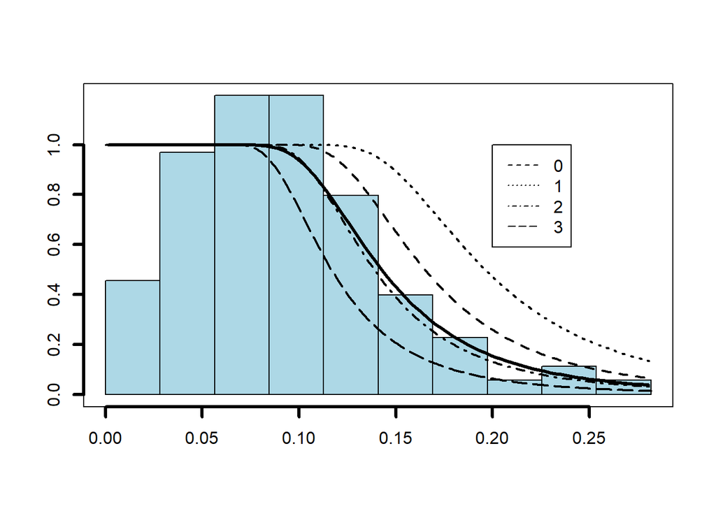

```r
plot(
    detfc.sea.hr,
    hazard.params = list(xvar = distdata$distance, alpha = 0.02),
    lwd = 3,
    showpoints = F,
    pl.col = "lightblue",
    xlab = "",
    ylab = "",
    border = T
)
add_df_covar_line(detfc.sea.hr, data.frame(seaState = na.omit(unique(distdata$seaState))), lwd=2, pdf = TRUE)

legend(x = 0.2, y = 1, legend = c("0", "1", "2", "3"), lty=2:5)
```

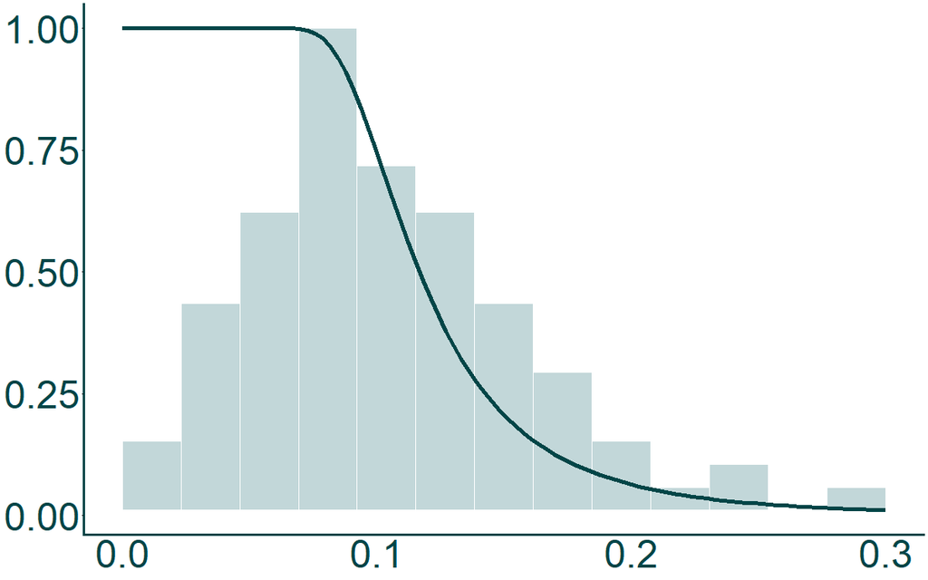

```r
gghist <- obsdata %>%
  ggplot(aes(x = distance)) +
  geom_histogram(bins = 13, col = "white", fill = "#C2D7D9")+
  rremove("x.axis")+
  rremove("xlab") +
  rremove("x.text") +
  rremove("x.ticks") +
    theme_void() + theme(       panel.grid.major = element_blank(),
        panel.grid.minor = element_blank(),
        panel.background = element_blank()
)

fndetection <- ggplot() +
    geom_line(data = data.frame(x = distances, y = y.val0),
                        aes(x = x, y = y),
                        col = "#004547", size = 2) +
    theme_half_open(11, rel_small = 1) +
  rremove("legend") +
    theme(
        axis.title.x = element_blank(),
        axis.title.y = element_blank(),
        axis.text.x = element_text(color = "#004547", size = 50),
        axis.text.y = element_text(color = "#004547", size = 50),
        axis.line.x = element_line(colour = "#004547", size = 1.1),
        axis.line.y = element_line(colour = "#004547", size = 1.1),
        axis.ticks.x = element_line(colour = "#004547", size = 1.1),
        panel.grid.major = element_blank(),
        panel.grid.minor = element_blank(),
        panel.background = element_blank()
    )


aligned_plots <- align_plots(gghist, fndetection, align="hv", axis="tblr")
plot_fndet <- ggdraw(aligned_plots[[1]]) + draw_plot(aligned_plots[[2]])

png("./img/plot_fndet.png", width = 1200, height = 750)
plot_fndet
dev.off()
```

# 3 Fonction de densité (covariables communes par session)

## 3.1 Analyse préliminaire : corrélation des covariables

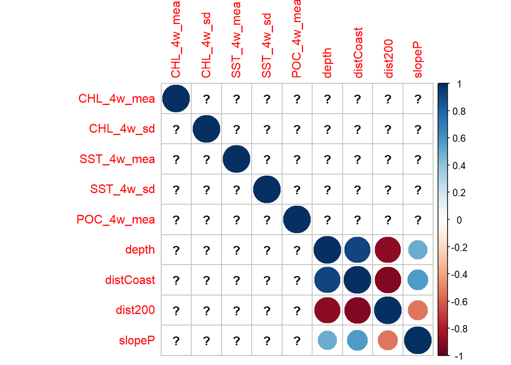

```r
library(corrplot)
corrplot(cor(segdata[,15:23]), method="circle")
```

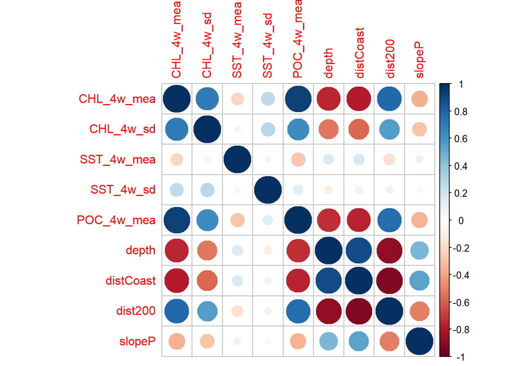

```r
corrplot(cor(predata[,7:15]), method="circle")
```

[figure not shown]

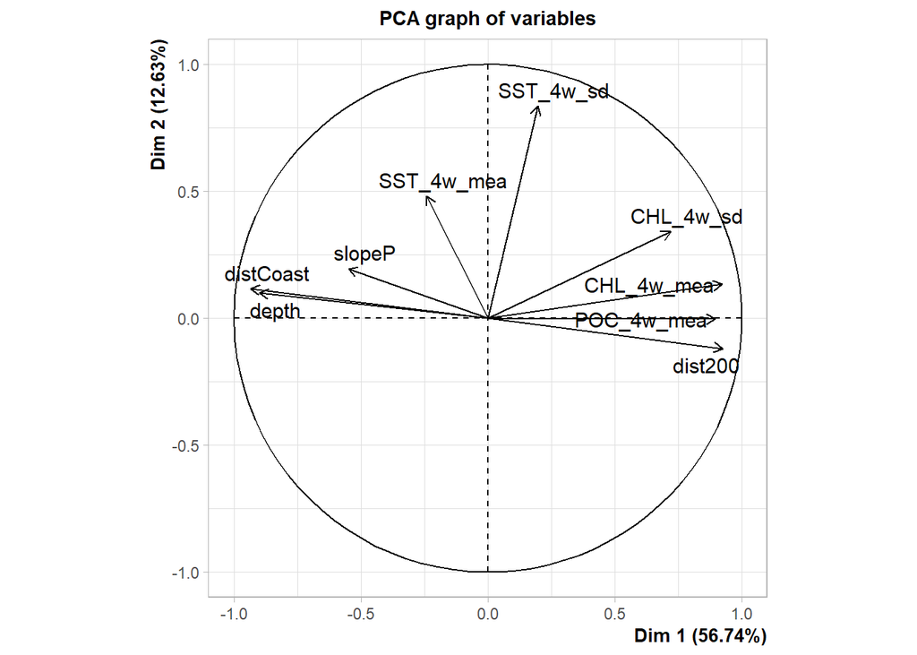

```
## **Results for the Principal Component Analysis (PCA)**
## The analysis was performed on 25992 individuals, described by 9 variables
## *The results are available in the following objects:
##
##    name               description
## 1  "$eig"             "eigenvalues"
## 2  "$var"             "results for the variables"
## 3  "$var$coord"       "coord. for the variables"
## 4  "$var$cor"         "correlations variables - dimensions"
## 5  "$var$cos2"        "cos2 for the variables"
## 6  "$var$contrib"     "contributions of the variables"
## 7  "$ind"             "results for the individuals"
## 8  "$ind$coord"       "coord. for the individuals"
## 9  "$ind$cos2"        "cos2 for the individuals"
## 10 "$ind$contrib"     "contributions of the individuals"
## 11 "$call"            "summary statistics"
## 12 "$call$centre"     "mean of the variables"
## 13 "$call$ecart.type" "standard error of the variables"
## 14 "$call$row.w"      "weights for the individuals"
## 15 "$call$col.w"      "weights for the variables"
```

```r
library(FactoMineR)
library(Factoshiny)

FactoMineR::PCA(predata[,7:15])
```

## 3.2 Sélection des covariables

On utilise la fonction `selec_dsm_aic_fwd` qui va permettre de sélectionner de manière forward les covariables à inclure dans le modèle dsm.

Cette fonction prend en arguments segdata, obsdata, la fonction de détection et un vecteur de toutes les covariables à tester. C’est une fonction récursive, elle peut donc aussi prendre en argument un vecteur des covariables déjà sélectionnées.

> On sélectionne les covariables sur l’ensemble des données, sans distinction de session. Ici, les AIC sont données pour `availability = 1`. L’algorithme pour les autres valeurs de disponibilité sélectionne les même covariables, seul l’AIC change.

```r
vct.spline.test = c("s(X, Y)", "s(depth)", "s(slopeP)", "s(distCoast)", "s(dist200)", "s(CHL_4w_mea)", "s(CHL_4w_sd)", "s(SST_4w_mea)", "s(SST_4w_sd)", "s(POC_4w_mea)")

selec_dsm_av1 <- selec_dsm_aic_fwd(segdata = segdata, obsdata = obsdata,
                                    detfc = detfc.sea.hr,
                                    vct.spline.test = vct.spline.test,
                                    availability = 1)
```

```
## [1] "----- SÃ©lection de la covariable numÃ©ro 1 -----"
## [1] "----- SÃ©lection de la covariable numÃ©ro 2 -----"
## [1] "----- SÃ©lection de la covariable numÃ©ro 3 -----"
## [1] "----- SÃ©lection de la covariable numÃ©ro 4 -----"
## [1] "L'AIC ne diminue plus en ajoutant une 4Ã¨me covariable"
```

```r
selec_dsm_av1
```

[output not shown]

```r
dsm_av1 <- selec_dsm_av1$dsm.selec
dsm_av1.pred <- predict(dsm_av1, predata, predata$Area)
```

## 3.3 Ajustement de la fonction de densité

> dsm pour $availability$ dépendante de on-shelf et off-shelf : On note “on-shelf” quand la profondeur est inférieure à 150m, et “off-shelf” si la profondeur est supérieure à 150m.

$$availability_{off-shelf}=0,1357617$$
$$availability_{on-shelf}=0,6332016$$

```r
segdata_tmp <- segdata %>% filter(month(date) == 5 | month(date) == 6)
obsdata_tmp <- obsdata %>% filter(session == 2)

# On choisit s(X, Y)
dsm_s2_av1 <- dsm(
                formula = count ~ s(SST_4w_mea) + s(X, Y) + s(CHL_4w_mea),
                ddf.obj = detfc.sea.hr,
                segment.data = segdata_tmp,
                observation.data = obsdata_tmp,
                method = 'REML',
                family = nb(),
                engine = 'gam',
                gamma = 1.4,
                availability = 1)


segdata_tmp <- segdata %>% filter(month(date) == 7 | month(date) == 8)
obsdata_tmp <- obsdata %>% filter(session == 3)

dsm_s3_av1 <- dsm(
                formula = count ~ s(SST_4w_mea) + s(X, Y) + s(CHL_4w_mea),
                ddf.obj = detfc.sea.hr,
                segment.data = segdata_tmp,
                observation.data = obsdata_tmp,
                method = 'REML',
                family = nb(),
                engine = 'gam',
                gamma = 1.4,
                availability = 1)


segdata_tmp <- segdata %>% filter(month(date) == 5 | month(date) == 6)
obsdata_tmp <- obsdata %>% filter(session == 2)

dsm_s2_av041 <- dsm(
                formula = count ~ s(SST_4w_mea) + s(X, Y) + s(CHL_4w_mea),
                ddf.obj = detfc.sea.hr,
                segment.data = segdata_tmp,
                observation.data = obsdata_tmp,
                method = 'REML',
                family = nb(),
                engine = 'gam',
                gamma = 1.4,
                availability = 0.41)


segdata_tmp <- segdata %>% filter(month(date) == 7 | month(date) == 8)
obsdata_tmp <- obsdata %>% filter(session == 3)

dsm_s3_av041 <- dsm(
                formula = count ~ s(SST_4w_mea) + s(X, Y) + s(CHL_4w_mea),
                ddf.obj = detfc.sea.hr,
                segment.data = segdata_tmp,
                observation.data = obsdata_tmp,
                method = 'REML',
                family = nb(),
                engine = 'gam',
                gamma = 1.4,
                availability = 0.41)

# On-shelf/off-shelf

distdata$availability = NA
for (i in 1:nrow(distdata)) {
    if (distdata$depth[i] <= 150) {
        distdata$availability[i] = 0.6332016
    } else{
        distdata$availability[i] = 0.1357617
    }
}

segdata_tmp <- segdata %>% filter(month(date) == 5 | month(date) == 6)
obsdata_tmp <- obsdata %>% filter(session == 2)
availability <- (distdata %>% filter(session == 2))$availability

dsm_s2_avshelf <- dsm(
                formula = count ~ s(SST_4w_mea) + s(X, Y) + s(CHL_4w_mea),
                ddf.obj = detfc.sea.hr,
                segment.data = segdata_tmp,
                observation.data = obsdata_tmp,
                method = 'REML',
                family = nb(),
                engine = 'gam',
                gamma = 1.4,
                availability = availability)

segdata_tmp <- segdata %>% filter(month(date) == 7 | month(date) == 8)
obsdata_tmp <- obsdata %>% filter(session == 3)
availability <- (distdata %>% filter(session == 3))$availability

dsm_s3_avshelf <- dsm(
                formula = count ~ s(SST_4w_mea) + s(X, Y) + s(CHL_4w_mea),
                ddf.obj = detfc.sea.hr,
                segment.data = segdata_tmp,
                observation.data = obsdata_tmp,
                method = 'REML',
                family = nb(),
                engine = 'gam',
                gamma = 1.4,
                availability = availability)
```

On peut visualiser le modèle GAM ajusté, par exemple pour le dsm de la session 2 avec une disponibilité à 1.

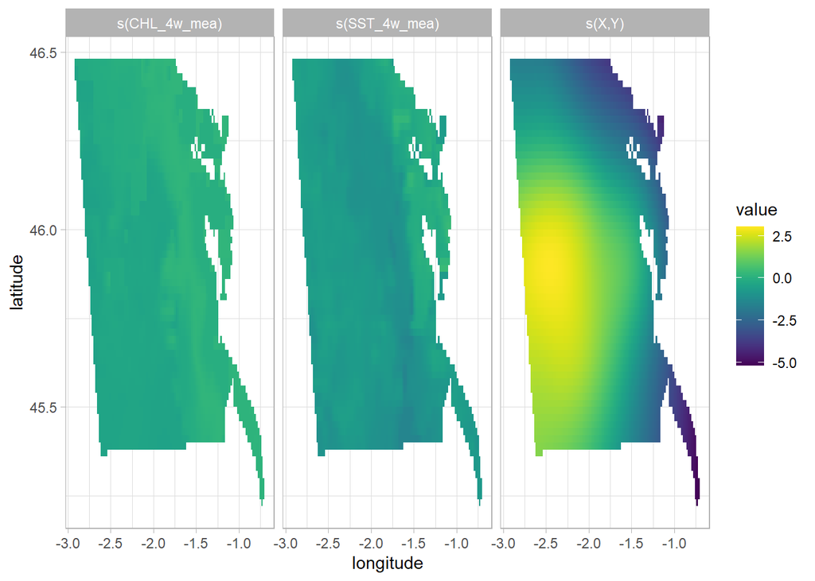

```r
plot_pred_by_term(dsm_s2_av1,
                                    predata,
                                    c("longitude","latitude")) + scale_fill_viridis()
```

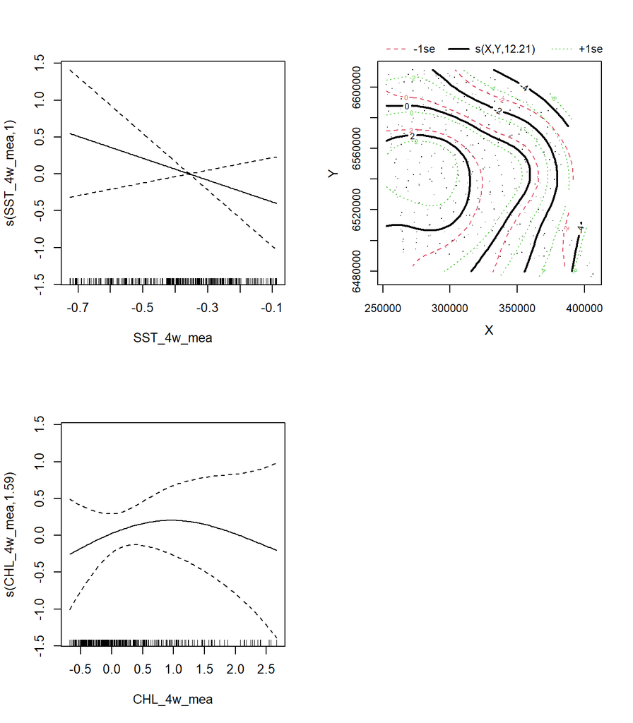

```r
par(mfrow = c(2,2))
plot.gam(dsm_s2_av1)
```

# 4 Prédiction de l’abondance

```r
predata_tmp2 <- predata %>% filter(session == 2)
predata_tmp3 <- predata %>% filter(session == 3)

dsm_s2_av1.pred <- predict(dsm_s2_av1, predata_tmp2, predata_tmp2$Area)
dsm_s3_av1.pred <- predict(dsm_s3_av1, predata_tmp3, predata_tmp3$Area)

dsm_s2_av041.pred <- predict(dsm_s2_av041, predata_tmp2, predata_tmp2$Area)
dsm_s3_av041.pred <- predict(dsm_s3_av041, predata_tmp3, predata_tmp3$Area)

dsm_s2_avshelf.pred <- predict(dsm_s2_avshelf, predata_tmp2, predata_tmp2$Area)
dsm_s3_avshelf.pred <- predict(dsm_s3_avshelf, predata_tmp3, predata_tmp3$Area)
```

## 4.1 Comparaison des résultats selon la valeur de disponibilité

```
## [1] "-------- Session 2 --------"
```

```
## [1] "Avec availaibility = 1, on estime qu'il y a 4386 requins au total dans la zone."
```

```
## [1] "Avec availaibility = 0.41, on estime qu'il y a 10507 requins au total dans la zone."
```

```
## [1] "Avec availaibility selon on/off shelf, on estime qu'il y a 6848 requins au total dans la zone."
```

```
## [1] "-------- Session 3 --------"
```

```
## [1] "Avec availaibility = 1, on estime qu'il y a 1456 requins au total dans la zone."
```

```
## [1] "Avec availaibility = 0.41, on estime qu'il y a 3508 requins au total dans la zone."
```

```
## [1] "Avec availaibility selon on/off shelf, on estime qu'il y a 2257 requins au total dans la zone."
```

```r
summary(dsm_s2_av1.pred)
```

```
##     Min.  1st Qu.   Median     Mean  3rd Qu.     Max.
## 0.001479 0.083645 0.489730 1.012422 1.553798 5.166905
```

```r
summary((segdata %>% filter(month(date) == 5 | month(date) == 6))$POC_4w_mea)
```

```
##    Min. 1st Qu.  Median    Mean 3rd Qu.    Max.    NA's
## -0.6847 -0.3139 -0.1138  0.2690  0.4112  2.6684       1
```

## 4.2 Cartes

```r
# Création de la carte vide
empty.map <- ggmap(get_stamenmap(
    bbox = make_bbox(
        lon = c(min(distdata$longitude), max(distdata$longitude)+0.8),
        lat = c(min(distdata$latitude), max(distdata$latitude)),
        f = 0.4
    ),
    zoom = 8,
    maptype = "toner-lite"
))
```

### 4.2.1 Session 2 et availability = 1

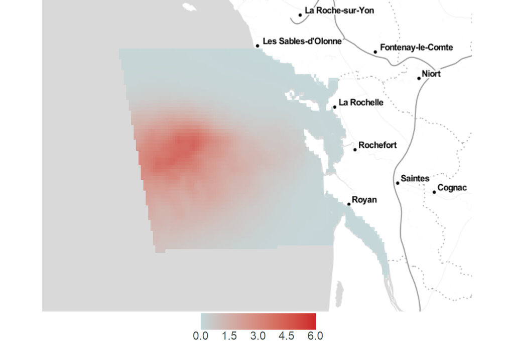

```r
map <- get_map_abundance(
    empty.map = empty.map,
    dsm.pred = dsm_s2_av1.pred,
    predata_tmp = predata_tmp2,
    session_selec = 2,
    segdata = segdata,
    distdata = distdata,
    abondance = TRUE,
    transects = FALSE,
    observations = FALSE,
    poster = TRUE
)

png("./img/dsm_s2_av1.pred.png",
        width = 1800,
        height = 1200)
map
dev.off()
```

### 4.2.2 Session 3 et availability = 1

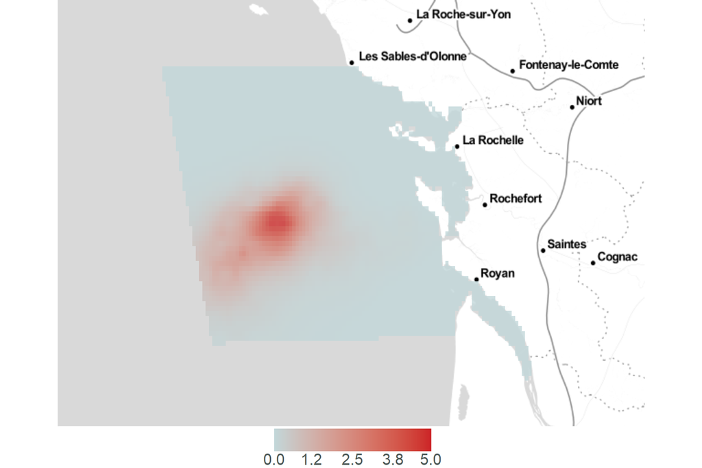

```r
map <- get_map_abundance(
    empty.map = empty.map,
    dsm.pred = dsm_s3_av1.pred,
    predata_tmp = predata_tmp3,
    session_selec = 3,
    segdata = segdata,
    distdata = distdata,
    abondance = TRUE,
    transects = FALSE,
    observations = FALSE,
    poster = TRUE
)

png("./img/dsm_s3_av1.pred.png", width = 1800, height = 1200)
map
dev.off()
```

### 4.2.3 Session 2 et availability = 0.41

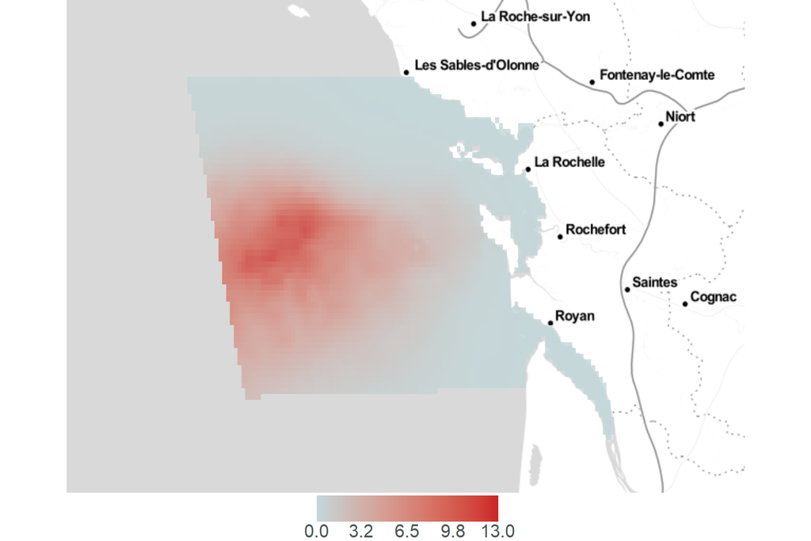

```r
map <- get_map_abundance(
    empty.map = empty.map,
    dsm.pred = dsm_s2_av041.pred,
    predata_tmp = predata_tmp2,
    session_selec = 2,
    segdata = segdata,
    distdata = distdata,
    abondance = TRUE,
    transects = FALSE,
    observations = FALSE,
    poster = TRUE
)

png("./img/dsm_s2_av041.pred.png", width = 1800, height = 1200)
map
dev.off()
```

### 4.2.4 Session 3 et availability = 0.41

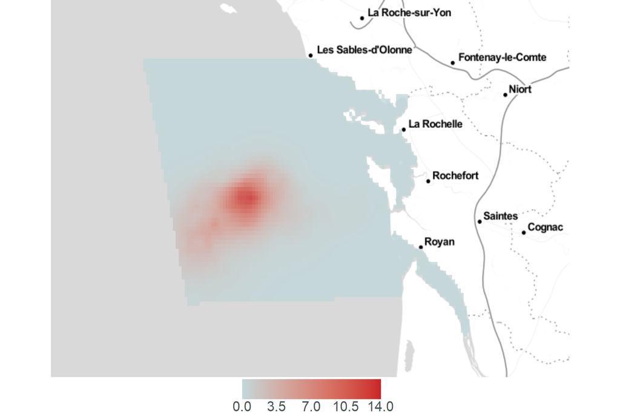

```r
map <- get_map_abundance(
    empty.map = empty.map,
    dsm.pred = dsm_s3_av041.pred,
    predata_tmp = predata_tmp3,
    session_selec = 3,
    segdata = segdata,
    distdata = distdata,
    abondance = TRUE,
    transects = FALSE,
    observations = FALSE,
    poster = TRUE
)

png("./img/dsm_s3_av041.pred.png",
        width = 1800,
        height = 1200)
map
dev.off()
```

### 4.2.5 Session 2 et availability = off/on shelf

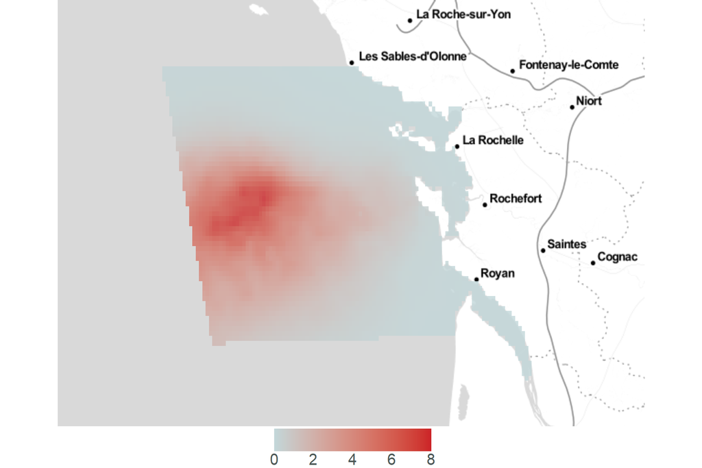

```r
map <- get_map_abundance(
    empty.map = empty.map,
    dsm.pred = dsm_s2_avshelf.pred,
    predata_tmp = predata_tmp2,
    session_selec = 2,
    segdata = segdata,
    distdata = distdata,
    abondance = TRUE,
    transects = FALSE,
    observations = FALSE,
    poster = TRUE
)

png("./img/dsm_s2_avshelf.pred.png",
        width = 1800,
        height = 1200)
map
dev.off()
```

### 4.2.6 Session 3 et availability = off/on shelf

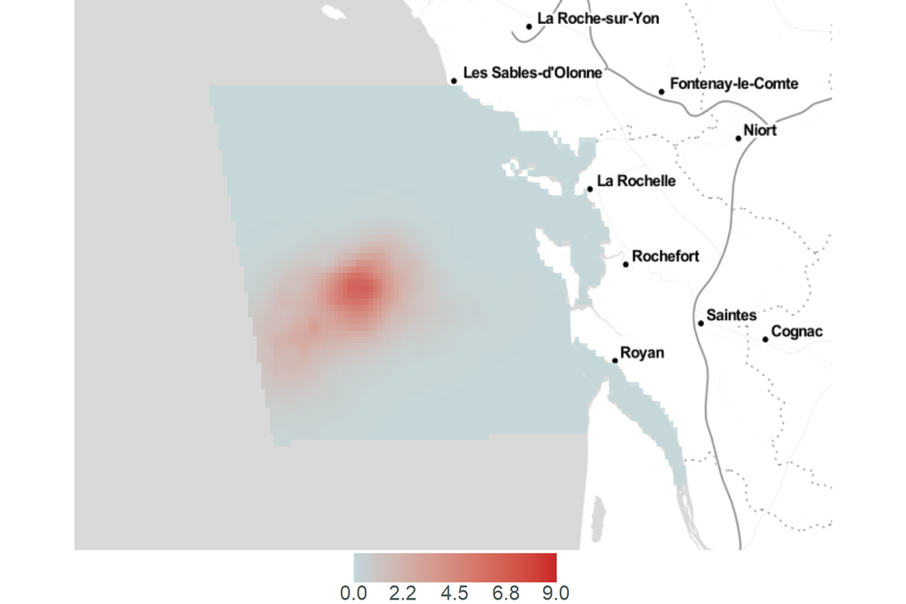

```r
map <- get_map_abundance(
    empty.map = empty.map,
    dsm.pred = dsm_s3_avshelf.pred,
    predata_tmp = predata_tmp3,
    session_selec = 3,
    segdata = segdata,
    distdata = distdata,
    abondance = TRUE,
    transects = FALSE,
    observations = FALSE,
    poster = TRUE
)

png("./img/dsm_s3_avshelf.pred.png",
        width = 1800,
        height = 1200)
map
dev.off()
```

# 5 Extrapolation sur gridata

## 5.1 predict

```r
gridata_tmp2 <- gridata %>% filter(session == 2)
gridata_tmp3 <- gridata %>% filter(session == 3)

dsm_s2_av1.pred.extr <- predict(dsm_s2_av1, gridata_tmp2, gridata_tmp2$Area)
dsm_s3_av1.pred.extr <- predict(dsm_s3_av1, gridata_tmp3, gridata_tmp3$Area)

dsm_s2_av041.pred.extr <- predict(dsm_s2_av041, gridata_tmp2, gridata_tmp2$Area)
dsm_s3_av041.pred.extr <- predict(dsm_s3_av041, gridata_tmp3, gridata_tmp3$Area)

dsm_s2_avshelf.pred.extr <- predict(dsm_s2_avshelf, gridata_tmp2, gridata_tmp2$Area)
dsm_s3_avshelf.pred.extr <- predict(dsm_s3_avshelf, gridata_tmp3, gridata_tmp3$Area)
```

```r
sum(dsm.pred.extr)
```

[output not shown]

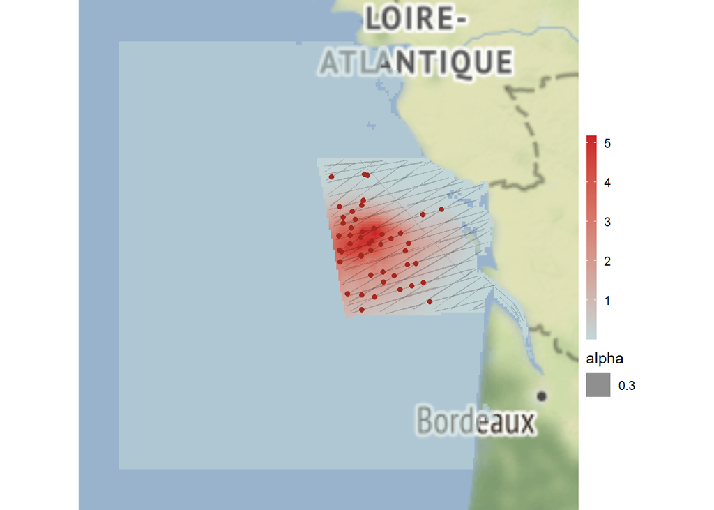

```r
empty.map2 <- ggmap(get_map(
    location = make_bbox(
        lon = c(min(gridata$lon), max(gridata$lon)),
        lat = c(min(gridata$lat), max(gridata$lat)),
        f = .1),
    zoom = 6,
    maptype = "satellite"
))

get_map_abundance_extr(empty.map = empty.map2,
                                    dsm.pred = dsm_s2_av1.pred,
                                    dsm.pred.extr = dsm_s2_av1.pred.extr,
                                    predata_tmp = predata_tmp2, gridata_tmp = gridata_tmp2,
                                    session_selec = 2,
                                    segdata = segdata,
                                    distdata = distdata,
                                    pal = c("#C2D7D9", "#CC2227"))
```

# 6 Exportation des résultats en Rdata

```r
# Fonction de détection
save(detfc.sea.hr,
         file = "resultats/detfc.Rdata")

# Modèles : dsm
save(dsm_s2_av1, dsm_s2_av041, dsm_s2_avshelf,
         dsm_s3_av1, dsm_s3_av041, dsm_s3_avshelf,
         file = "resultats/modeles_dsm.RData")

# Résultats de la prédiction : dsm.pred
save(dsm_s2_av1.pred, dsm_s2_av041.pred, dsm_s2_avshelf.pred,
         dsm_s3_av1.pred, dsm_s3_av041.pred, dsm_s3_avshelf.pred,
         file = "resultats/modeles_dsm.pred.RData")
```